# #TidyTuesday 2 / 10.9.2019: Week 37 Amusement Park Injuries

10/9/2019

> (1/n) Michael Pollan’s advice if he taught [#Rstats](https://twitter.com/hashtag/Rstats?src=hash&ref_src=twsrc%5Etfw)/[#Python](https://twitter.com/hashtag/Python?src=hash&ref_src=twsrc%5Etfw) programming for [@datacarpentry](https://twitter.com/datacarpentry?ref_src=twsrc%5Etfw):  
> 1. Write code  
> 2. Not too much  
> 3. Mostly plots

> — Dr. Michael Koontz (@_mikoontz) [July 26, 2016](https://twitter.com/_mikoontz/status/758021742078025728?ref_src=twsrc%5Etfw)

## Recap

- .Rmd (R Markdown) е околината во која ќе работиме;
- Нов R Notebook: Мени: File -> New File -> R notebook
- Корисни кратенки:
  - code chunks (ctrl+alt+i)
  - pipes (ctrl+shift+m)
  - view()

## Околината на RStudio

- Отвори RStudio

## The tidyverse

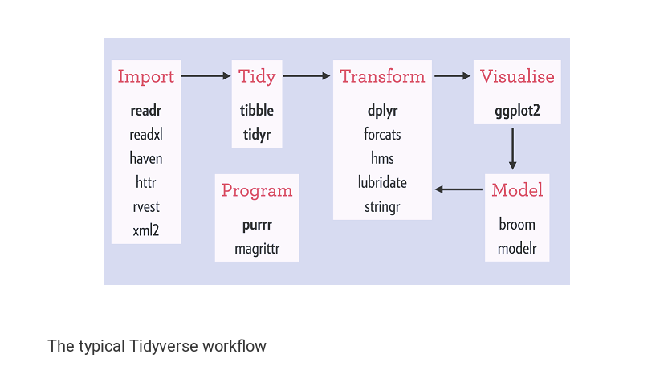

tidiverse workflow

The tidyverse is an “opinionated collection of R packages designed for data science. All packages share an underlying design philosophy, grammar, and data structures.” (source: https://thomasmock.netlify.com/post/tidytuesday-a-weekly-social-data-project-in-r/)

## TidyTuesday 37 недела, 2 пат КИКА

- Податоци на [github](https://github.com/rfordatascience/tidytuesday/tree/master/data/2019/2019-09-10)
- Добар пример за тоа ако на пример работите во осигурителна куќа и ви речат ајде да видиме што да се прави за полиси за осигурување за повреди во забавни паркови.

## TidyTuesday hints за новите податоци

A lot of free text this week, some inconsistent NAs (n/a, N/A) and dates (ymd, dmy). A good chance to do some data cleaning and then take a look at frequency, type of injury, and analyze free text.

## The code 1

Load the libraries

```r
library(tidyverse)
```

## The code 2

Load the data from github (*NOTE: lines are broken for readibility*)

```r
tx_injuries <-
readr::read_csv("https://raw.githubusercontent.com/rfordatascience/
tidytuesday/master/data/2019/2019-09-10/tx_injuries.csv")

safer_parks <-
readr::read_csv("https://raw.githubusercontent.com/rfordatascience/
tidytuesday/master/data/2019/2019-09-10/saferparks.csv")
```

## The code 3 - чистење на податоците #1

1. Среди ги сите NA вредности

Прашање: Колку сѐ можни форми на NA има во податоците?

```r
glimpse(tx_injuries)
map(tx_injuries, unique)
```

## The code 3 - чистење на податоците #2

“N/A”, “n/a” - колку што можевме да видиме? **na_if**

```r
tx_injuries <- tx_injuries %>%
    mutate(age = na_if(age, "n/a")) %>%
    mutate(age = na_if(age, "N/A")) %>%
    mutate(age = na_if(age, "0")) %>%
    mutate(age = as.numeric(age)) %>%
    mutate(gender = na_if(gender, "n/a")) %>%
    mutate(gender = na_if(gender, "N/A")) %>%
    mutate(gender=str_to_upper(gender)) %>%
    mutate(gender = as_factor(gender)) %>%
    mutate(injury_date = na_if(injury_date, "n/a")) %>%
    mutate(injury_date = na_if(injury_date, "#########"))

map(tx_injuries, unique)
```

## The code 3 - чистење на податоците #3

Комплицирано и компјутеризирано барање на NA (за домашна :))

```r
# make a function to mutate a column to fix NAs
fix_na <- function(vect, na_strings) {
  vect[vect %in% na_strings] <- NA
  return(vect)
}

# find possible NA values
possible_na <-
  tx_injuries %>%
  gather(col_name, value) %>%
  filter(str_detect(value, "^n|^N"), str_length(value) < 5) %>%
  distinct(value, .keep_all = FALSE) %>%
  filter(!value %in% c("Neck", "Nose", "neck")) %>%
  unlist %>%
  unname()

tx_injuries_na_fixed <- tx_injuries %>%
  mutate_all(.funs = fix_na, na_strings = possible_na)
```

## The code 3 - чистење на податоците #4

Датуми - **lubridate**

```r
library(lubridate)

tx_injuries$injury_date

tx_injuries <- tx_injuries %>%
    mutate(injury_date = case_when(
      str_length(injury_date) == 5 ~ as_date(
        as.numeric(injury_date), origin='1899-12-30'),
      str_detect(injury_date, "/") == TRUE ~ mdy(injury_date),
      TRUE ~ as.Date(NA)
      ))


tx_injuries$injury_date
```

## The code 4 - графици #1

Ако се присетите на чистењето на податоците, некако излегува дека решивме да работиме со три променливи кои се различни по тип: `age`, `gender`, `injury_date`.

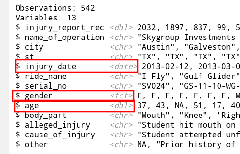

glimpse

```r
glimpse(tx_injuries)
```

## The code 4 - графици #2

Template за графици

```r
ggplot(data = <DATA>) +
  <GEOM_FUNCTION>(mapping = aes(<MAPPINGS>))
```

Извор: https://r4ds.had.co.nz/data-visualisation.html#first-steps

MAPPING: A `variable` is *mapped* onto a `geom`.

Examples: `age` is mapped to `x`, `gender` is mapped to `fill`

Many `geoms`. They have a corresponding `stat` function that transforms the data to make it suitable for the `geom` (?stat_boxplot)

## The code 4 - графици #3

```r
ggplot(data = drop_na(tx_injuries, gender)) +
  geom_histogram(mapping = aes(x = age, fill = gender),
                 na.rm = TRUE, color="white") +
  labs(x="Години", y="Број") +
  labs(title="Број на повреди по години по пол", fill = "Пол") +
  theme_minimal()
```

[output not shown]

## The code 4 - графици #4

```r
ggplot(data = drop_na(tx_injuries, gender)) +
  geom_point(mapping = aes(x = age, y = injury_date, color=gender)) +
  labs(x="Година", y="Возраст") +
  labs(title="Повреди по години по возраст") +
  #facet_wrap("gender", ncol=2)
  theme_minimal()
```

[output not shown]

## The code 5 - графици #5

```r
#install.packages("ggridges")

library(ggridges)

tx_injuries %>% select(age, gender, injury_date) %>%
  mutate(Month=month.name[month(injury_date)]) %>%
  mutate(Year=factor(year(injury_date))) %>%
  group_by(Year) %>%
  mutate(Day_of_year=injury_date-min(injury_date)) %>%
  drop_na(Year, Day_of_year, gender) %>%
  ggplot(data=.) +
    geom_density_ridges(mapping = aes(
      x=Day_of_year, y=Year, fill=gender), alpha=.5) +
    facet_wrap("gender", ncol=2)
```

[output not shown]

## The code 7 - графици #6

```r
library(ggridges)

tx_injuries %>% select(age, gender, injury_date) %>%
  mutate(Month=month.name[month(injury_date)]) %>%
  mutate(Year=factor(year(injury_date))) %>%
  drop_na(Month, Year, gender) %>%
  group_by(Year, Month, gender) %>%
  tally() %>%
  ggplot(data=.) +
    geom_tile(aes(y=Month, x=Year, fill=n), color="white") +
    facet_wrap("gender", ncol=2) +
      theme_classic()
```

[output not shown]

## R референци

- R4DS slack канал наменет за почетници што вежбаа со #TidyTuesday
- R for Data science (https://r4ds.had.co.nz/)
- Advanced R (http://adv-r.had.co.nz/)
- TidyTuesday podcast (https://podtail.com/podcast/tidy-tuesday/)